# Introduction: Injustice at Work

Our data source explores the relationship between attributes of the complainants/complaints regarding Employee Discrimination charges and the outcomes of each charge.

For our project, we will analyze data to see if there are any trends in complaintant demographics/the basis of complaints against the workplace and try to find if there are are factors that make complaints against employers more or less successful. This problem matters because it could reveal some bias within workplace complaints and their outcomes. If the outcome of this analysis does reveal bias, it could reveal the demographics or type of complaints that have bias against them and hopefully bring more awareness to any predjudice that exists within this system.

Due to working on our personal machines, we chose 25,000 rows of data at random to represent the full dataset. The original dataset can be found here: https://github.com/PublicI/employment-discrimination/blob/master/data/complaints_10.txt

According to the Injustice at Work Center, each attribute is defined as follows:

- Unique ID: unique identifier for each case (a case is a collection of related charges)
- State Code: complainant state
- No of Employees Code: code indicating the approximate number of employees working for respondent employer
- No of Employees: approximate number of employees working for respondent employer
- NAICS Code: North American Industry Classification System code of respondent employer
- NAICS Description: North American Industry Classification System description of respondent company (e.g., crude petroleum and natural gas extraction)
- Institution Type Code: classification code of respondent employer
- Institution Type: classification of respondent employer (e.g., private employer)
- CP Date of Birth: complainant’s date of birth
- CP Sex: complainant’s gender
- Date First Office: date charge was filed
- Date FEPA Sent to EEOC: date charge was forwarded to the EEOC
- Closure Date: date investigation of case was closed
- Closure Code: code indicating how case was closed
- Closure Type: description indicating how case was closed (e.g., no cause finding issued)
- Monetary Benefits: monetary benefit complainant received
- Statute Code: code for statute under which charge was filed
- Statute: statute under which charge was filed (e.g., Americans with Disabilities Act)
- Basis Code: code for basis of discrimination
- Basis: basis of discrimination (e.g., race-black/African American)
- Issue Code: type code for adverse action alleged by complainant
- Issue: adverse action alleged by complainant (e.g., harassment)
- Court Filing Date: date complainant filed a lawsuit
- Civil Action Number: case number of lawsuit
- Court: court in which lawsuit was filed
- Litigation Resolution Date: date lawsuit was resolved
- Litigation Monetary Benefits: monetary damages recovered through lawsuit
- Litigation Case Type: case type of lawsuit

Our analysis will be looking to classify data by "Closure Code", and we have deduced that the possible predictive attributes are as follows:

- State Code: complainant state
- No of Employees Code: code indicating the approximate number of employees working for respondent employer
- NAICS Code: North American Industry Classification System code of respondent employer
- Institution Type Code: classification code of respondent employer
- CP Date of Birth: complainant’s date of birth *(we feature engineer this to get age)
- CP Sex: complainant’s gender
- Basis Code: code for basis of discrimination
- Issue Code: type code for adverse action alleged by complainant
- Litigation Case Type: case type of lawsuit

# Preprocessing/Cleaning

## Pandas Settings

```python
import pandas as pd

pd.set_option("display.max_columns", 50)
pd.set_option("display.max_rows", 100)
pd.options.display.float_format = "{:,.2f}".format
```

We are taking 25,000 rows from our dataset which included around 343,000 rows due to the limitations of doing this project on personal machines.

```python
# code below was used to obtain a sample of 25,000 rows from the dataset.
'''
data = pd.read_csv("complaints_10.txt", sep="\t", skiprows=1,
                      dtype={1: str},
                      names=["unique_id", "state_code", "num_employee_code", "num_employees",
                             "naics_code", "naics_desc", "inst_type_code", "inst_type",
                             "birth_date", "sex", "date_filed", "date_sent_eeoc", "date_closed",
                             "closure_code", "closure_action", "monetary_benefits", "statute_code",
                             "statute", "basis_code", "basis", "issue_code", "issue",
                             "court_filing_date", "civil_action_num", "court", "resolution_date",
                             "litigation_monetary_benefits", "litigation_case_type"])

cols_to_drop = ['unique_id', 'num_employees', 'naics_desc',
                'inst_type', 'date_closed', "closure_action",
                "monetary_benefits", "statute_code", "statute",
                "basis", "issue", "court_filing_date", "date_sent_eeoc",
                "civil_action_num", "court", "resolution_date",
                "litigation_monetary_benefits"
                ]

data = data.drop(cols_to_drop, axis = 1)
data = data.sample(n = 25_000)
data.to_csv('complaints_10-subset.csv', index=False)
'''
data = pd.read_csv('complaints_10-subset.csv')
data.head()
```

|  | state_code | num_employee_code | naics_code | inst_type_code | birth_date | sex | date_filed | closure_code | basis_code | issue_code | litigation_case_type |
| --- | --- | --- | --- | --- | --- | --- | --- | --- | --- | --- | --- |
| 0 | TX | C | nan | E | 05/28/71 | F | 06/09/10 | M3 | GF | S5 | NaN |
| 1 | NV | D | nan | E | 04/18/66 | NaN | 05/11/10 | M3 | AC | D2 | NaN |
| 2 | MA | NaN | 446,110.00 | E | 03/17/81 | F | 02/10/10 | M3 | OR | W1 | NaN |
| 3 | PA | B | nan | G | 07/18/56 | F | 11/03/09 | M3 | TP | T2 | NaN |
| 4 | CA | A | nan | G | 12/14/61 | M | 03/17/10 | M3 | VB | R6 | NaN |

Calculate age of complaintant from birth date and cleaning the age column

```python
def get_age(dob, filing_date):
    if pd.isna(dob):
        return 0
    filing_year = int(str(filing_date)[-2:]) + 2000
    filing_year = filing_year if filing_year <= 2010 else og_year - 100
    birth_year = int(str(dob)[-2:]) + 2000
    birth_year = birth_year if birth_year <= 2010 else birth_year - 100
    age = filing_year - birth_year
    return age if age > 16 else 0

def get_year(date):
    if pd.isna(date):
        return 0
    og_year = int(str(date)[-2:]) + 2000
    year = og_year if og_year <= 2010 else og_year - 100
    og_year = year
    return og_year

data['age'] = data.apply(lambda x: get_age(x['birth_date'], x['date_filed']), axis=1)
data = data.drop(['birth_date'], axis = 1)
data = data.drop(['date_filed'], axis = 1)
```

Clean the newly created "age" field

```python
from datetime import timedelta, date
import numpy as np

# Delete these row indexes from dataFrame. age is outlier
indexNames = data[ data['age'] >= 78 ].index
data.drop(indexNames , inplace=True)

data['age'] = data['age'].replace(0, np.nan) # to avoid counting in the zeroes
data['age'] = data['age'].replace(np.nan, data['age'].mean())

data.head()
```

|  | state_code | num_employee_code | naics_code | inst_type_code | sex | closure_code | basis_code | issue_code | litigation_case_type | age |
| --- | --- | --- | --- | --- | --- | --- | --- | --- | --- | --- |
| 0 | TX | C | nan | E | F | M3 | GF | S5 | NaN | 39.00 |
| 1 | NV | D | nan | E | NaN | M3 | AC | D2 | NaN | 44.00 |
| 2 | MA | NaN | 446,110.00 | E | F | M3 | OR | W1 | NaN | 29.00 |
| 3 | PA | B | nan | G | F | M3 | TP | T2 | NaN | 53.00 |
| 4 | CA | A | nan | G | M | M3 | VB | R6 | NaN | 49.00 |

```python
data["litigation_case_type"].fillna("No Litigation", inplace = True)
data["naics_code"].fillna(0.0, inplace = True)
data["state_code"].fillna(data["state_code"].mode()[0], inplace = True)
data["sex"].fillna(data["sex"].mode()[0], inplace = True)
data["num_employee_code"].fillna(data["num_employee_code"].mode()[0], inplace = True)
# drop rows with no basis_code OR no closure_code.
data = data.dropna()

data.isna().sum()
```

```
state_code              0
num_employee_code       0
naics_code              0
inst_type_code          0
sex                     0
closure_code            0
basis_code              0
issue_code              0
litigation_case_type    0
age                     0
dtype: int64
```

## Grouping of Classes

We determined this grouping by using the following guide to show explanations of the codes meaning: https://www.umass.edu/eeodatanet/sites/default/files/IMS%20Codes.pdf Further explanation on terminology can be found here: https://www.eeoc.gov/eeoc/statistics/enforcement/definitions.cfm)

Class 0 (in favor of employer) codes:

- M3 - No cause finding issued
- M5 - Conciliation failure
- X7 - Closed due to court decision

Class 1 (in favor of employee) codes:

- M1 - Withdrawal with benefits
- M2 - Settlement with Benefits
- M4 - Successful Conciliation
- X1 - CP Filed Suit

Below, we change values of closure code to their appropriate class of 0, 1, and 2 as described in "Grouping of Classes".

```python
to_replace = {"M3" : 0, "M5" : 0, "X7" : 0, "M1" : 1, "M2" : 1, "M4" : 1, "X1" : 1, "X3" : 2, "X9" : 2, "Y1" : 2, "N2" : 2, "Y2" : 2, "X2" : 2}
data["closure_code"].replace(to_replace, inplace = True)
unusedClass = data[ data["closure_code"] == 2].index
data.drop(unusedClass , inplace=True)
data['closure_code'] = data['closure_code'].astype(int)
```

## Class Imbalance Problem Resolution

After running our original data set through classifiers, we were achieving about a 75% accuracy rate best case. However, once we began to look into it, we realized our false positive rate (falsely classifying employees whose case was ruled in favor of them to those who did not) was extremely high at over 96% best case.

We looked into the data split and found that class 0 had 10138 datapoints, while class 1 had 3353 datapoints. This lead us to realize it was at least partially a class imbalance problem, so we chose to resolve that using resampling the minority class (class 1) with replacement.

```python
from sklearn.utils import resample
df_majority = data[data.closure_code==0]
df_minority = data[data.closure_code==1]
df_minority_upsampled = resample(df_minority, replace=True, n_samples=data.closure_code.value_counts()[0], random_state=123)
data = pd.concat([df_majority, df_minority_upsampled])
data.closure_code.value_counts()
```

```
1    10138
0    10138
Name: closure_code, dtype: int64
```

### Fix "NAICS code" column

The important part of this code is the first three digits which indicates the sector and the subsector of the company. More info on how to read NAICS codes: https://www.investopedia.com/terms/n/naics.asp

```python
# get sector and subsector only
def extract_sector_and_subsector(naics_code):
    if naics_code == '0.0': # missing
        naics_code = "0"
        return "0"
    sector_subsector = naics_code[0:3] # first three digits
    naics_code = sector_subsector
    return naics_code

data["naics_code"] = data["naics_code"].astype(str)
data["naics_code"] = data["naics_code"].replace(",","")
data["naics_code"] = data["naics_code"].apply(extract_sector_and_subsector)
data["naics_code"] = data["naics_code"].astype(int) # convert to int. faster to work with
data.head()
data['closure_code'].value_counts()
```

```
1    10138
0    10138
Name: closure_code, dtype: int64
```

### Fix "Basis Code" column

When looking at how the basis of discrimination allegations were grouped by Statue code, we were unsatisfied by how broad the categories were; therefore, we decided to group each basis into our own categories as follows:

#### Race:

- RB: Race-Black/African American
- RW: Race-White
- OC: Color
- RS: Race-Asian
- RM: RM Race-Bi-Racial/Multi-Racial
- RI: Race-American Indian/Alaska Native
- RH: Race-Native Hawaiian/Pacific Islander
- RO: Race-Other - Obsolete

#### National Origin:

- NH: National Origin-Hispanic
- NO: National Origin-Other
- NM: National Origin-Mexican
- NE: National Origin-East Indian
- FB: Ancestry

#### Religion:

- AO: Religion-Other
- AM: Religion-Muslim
- AJ: Religion-Jewish
- AP: Religion-Protestant
- AC: Religion-Catholic
- AA: Religion-7th Day Adventist
- AS: Religion-Sikhs

#### Age:

- OA: Age

#### Physical Health:

- Z2: Other Disability
- Z3: Record Of Disability
- Z4: Regarded as Disabled
- VB: Nonparalytic Orthopedic Impairment
- T3: Orthopedic/Structural Back Impairment
- U2: Diabetes
- W3: Heart/Cardiovascular
- U1: Cancer
- W2: Hearing Impairment
- Z1: Vision Impairment
- WJ: Multiple Sclerosis
- T2: Asthma
- XC: Other Pulmo/Respiratory
- WG: Epilepsy
- W1: Gastrointestinal
- WD: Brain/Head Injury (Traumatic)
- TP: Blood (Other)
- T1: Allergies
- TN: HIV
- W4: Kidney Impairment
- T7: Genetic Information Discrimination (GINA Only)
- OH: Handicap (Not ADA)
- VA: Missing Digits/Limbs
- WK: Paralysis
- Y1: Speech Impairment
- WE: Cerebral Palsy
- T4: Chemical Sensitivity
- WF: Cumulative Trauma Disorder
- U4: Dwarfism
- U3: Disfigurement
- XA: Cystic Fibrosis
- Z6: Genetic Discrimination (ADA Only)
- XB: Tuberculosis

#### Mental Health:

- UB: Depression
- UA: Other Anxiety Disorder
- UL: Other Neurological
- UC: Manic Depression (Bi-polar)
- WH: Learning Disability
- U6: Post-Traumatic Stress Disorder
- UE: Other Psychiatric Disorders
- YB: Drug Addiction
- UD: Schizophrenia
- YA: Alcoholism
- W5: Mental Retardation
- WA: Autism
- WC: Alzheimers

#### Gender:

- GF: Sex-Female
- GM: Sex-Male
- GP: Sex-Pregnancy
- PF: Equal Pay-Female
- PM: Equal Pay-Male

#### Retaliation:

- OR: Retaliation

#### Other:

- OO: Other
- Z5: Relationship/Assn.

```python
basis_grouping = {}
basis_grouping.update(dict.fromkeys(["RB", "RW", "OC", "RS", "RM", "RI", "RH", "RO"], "Race"))
basis_grouping.update(dict.fromkeys(["NH", "NO", "NM", "NE", "FB"], "National Origin"))
basis_grouping.update(dict.fromkeys(["AO", "AM", "AJ", "AP", "AC", "AA", "AS"], "Religion"))
basis_grouping.update(dict.fromkeys(["OA"], "Age"))
basis_grouping.update(dict.fromkeys(["Z2", "Z3", "Z4", "VB", "T3", "U2", "W3", "U1", "W2", "Z1", "WJ", "T2", "XC", "WG", "W1", "WD", "TP", "T1", "TN", "W4", "T7", "OH", "VA", "WK", "Y1", "WE", "T4", "WF", "U4", "U3", "XA", "Z6", "XB"], "Physical Health"))
basis_grouping.update(dict.fromkeys(["UB", "UA", "UL", "UC", "WH", "U6", "UE", "YB", "UD", "YA", "W5", "WA", "WC"], "Mental Health"))
basis_grouping.update(dict.fromkeys(["GF", "GM", "GP", "PF", "PM"], "Gender"))
basis_grouping.update(dict.fromkeys(["OR"], "Retaliation"))
basis_grouping.update(dict.fromkeys(["OO", "Z5"], "Other"))

data["basis_code"].replace(basis_grouping, inplace = True)

data.head()
```

|  | state_code | num_employee_code | naics_code | inst_type_code | sex | closure_code | basis_code | issue_code | litigation_case_type | age |
| --- | --- | --- | --- | --- | --- | --- | --- | --- | --- | --- |
| 0 | TX | C | 0 | E | F | 0 | Gender | S5 | No Litigation | 39.00 |
| 1 | NV | D | 0 | E | F | 0 | Religion | D2 | No Litigation | 44.00 |
| 2 | MA | D | 446 | E | F | 0 | Retaliation | W1 | No Litigation | 29.00 |
| 3 | PA | B | 0 | G | F | 0 | Physical Health | T2 | No Litigation | 53.00 |
| 4 | CA | A | 0 | G | M | 0 | Physical Health | R6 | No Litigation | 49.00 |

### Fix "Issue Code" column

Including each individual basis would have increased the dimensionality of our dataset too greatly; therefore, we decided to group each ISSUE into our own categories as follows:

#### Suspension/Layoff:

- S5: Suspension
- D2: Discharge
- L1: Layoff
- C1: Constructive Discharge
- R5: Retirement-Involuntary

#### Monetary:

- W1: Wages
- B2: Benefits-Retirement/Pension
- B5: Severance Pay Denied
- B1: Benefits
- B6: Early Retirement Incentive

#### Hiring/Status:

- H2: Hiring
- P3: Promotion
- T1: Tenure
- R4: Reinstatement
- A3: Assignment
- R2: References Unfavorable
- T4: Training
- S3: Seniority
- A2: Apprenticeship
- R3: Referral
- Q1: Qualifications
- J1: Job Classification
- D1: Demotion
- R1: Recall

#### Workers Rights:

- U1: Union Representation
- F1: Filing EEO Forms
- R6: Reasonable Accomodation
- P5: Posting Notices
- P6: Breach of Confidentiality
- P4: Prohibited Medical Inquiry/Exam
- B3: Benefits-Insurance
- T3: Testing
- B4: Waivers
- R7: Record Keeping Violation
- T2: Terms/Conditions

#### Exclusion:

- L3: Other Language/Accent Issue
- L2: English Language Only Rule
- E1: Exclusion
- S1: Segregated Facilities
- M1: Maternity

#### Harassment:

- H1: Harassment
- S4: Sexual Harassment

#### Aggression:

- I1: Intimidation
- D3: Discipline

#### Other:

- O1: Other

```python
issue_grouping = {}
issue_grouping.update(dict.fromkeys(["S5", "D2", "L1", "C1", "R5"], "Suspension/Layoff"))
issue_grouping.update(dict.fromkeys(["W1", "B2", "B5", "B1", "B6"], "Monetary"))
issue_grouping.update(dict.fromkeys(["H2", "P3", "T1", "R4", "A3", "R2", "T4", "S3", "A2", "R3", "Q1", "J1", "D1", "R1"], "Hiring/Status"))
issue_grouping.update(dict.fromkeys(["U1", "F1", "R6", "P5", "P6", "P4", "B3", "T3", "B4", "T2", "R7"], "Workers Rights"))
issue_grouping.update(dict.fromkeys(["L3", "L2", "E1", "S1", "M1"], "Exclusion"))
issue_grouping.update(dict.fromkeys(["H1", "S4"], "Harassment"))
issue_grouping.update(dict.fromkeys(["I1", "D3"], "Aggression"))
issue_grouping.update(dict.fromkeys(["O1"], "Other"))

data["issue_code"].replace(issue_grouping, inplace = True)

data.head()
```

|  | state_code | num_employee_code | naics_code | inst_type_code | sex | closure_code | basis_code | issue_code | litigation_case_type | age |
| --- | --- | --- | --- | --- | --- | --- | --- | --- | --- | --- |
| 0 | TX | C | 0 | E | F | 0 | Gender | Suspension/Layoff | No Litigation | 39.00 |
| 1 | NV | D | 0 | E | F | 0 | Religion | Suspension/Layoff | No Litigation | 44.00 |
| 2 | MA | D | 446 | E | F | 0 | Retaliation | Monetary | No Litigation | 29.00 |
| 3 | PA | B | 0 | G | F | 0 | Physical Health | Workers Rights | No Litigation | 53.00 |
| 4 | CA | A | 0 | G | M | 0 | Physical Health | Workers Rights | No Litigation | 49.00 |

# Model Training

### Separating the class label from features

```python
labels = data['closure_code']
labels_flat = labels.values.ravel() # to use later
features = data.drop(['closure_code'],axis=1)
```

## Decision Tree Classifier

[output not shown]

```
Train Size: 16220
Test Size: 4056
Best params:
{'max_depth': 15, 'max_features': 8, 'min_samples_leaf': 16}

Best Accuracy:
64.88955851129805
AUC Score:
64.5129006397982
```

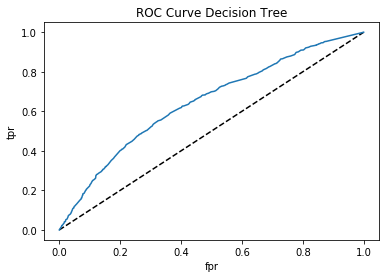

```
Confusion Matrix:
[[6323 3815]
 [3368 6770]]
FP Rate: 37.63069638982048
```

```python
from sklearn.tree import DecisionTreeClassifier, plot_tree
from sklearn.model_selection import train_test_split, cross_val_score, cross_val_predict
from sklearn import preprocessing
from sklearn.metrics import confusion_matrix, accuracy_score, roc_curve, roc_auc_score
from sklearn.model_selection import GridSearchCV
import matplotlib.pyplot as plt



def convert(data):
    number = preprocessing.LabelEncoder()
    data['state_code'] = number.fit_transform(data.state_code)
    data['num_employee_code'] = number.fit_transform(data.num_employee_code)
    data['naics_code'] = number.fit_transform(data.naics_code)
    data['inst_type_code'] = number.fit_transform(data.inst_type_code)
    data['sex'] = number.fit_transform(data.sex)
    data['basis_code'] = number.fit_transform(data.basis_code)
    data['issue_code'] = number.fit_transform(data.issue_code)
    data['litigation_case_type'] = number.fit_transform(data.litigation_case_type)
    data=data.fillna(-999)
    return data


features_train, features_test, labels_train, labels_test = train_test_split(features, labels, test_size=0.20)
features_train = convert(features_train)
features_test = convert(features_test)
assert features_train.shape[0] == labels_train.shape[0]
assert features_test.shape[0] == labels_test.shape[0]
print("Train Size:", features_train.shape[0])
print("Test Size:", features_test.shape[0])

numerical_features = convert(features)

'''
We tested the model with the following hyper-parameters:
    - max_depth: range(5, 50)
    - min_samples_leaf: range(5, 50)
    - max_features": range(1, 9)

it took around 30 minutes and we got the following:
    Best params: {'max_depth': 5, 'max_features': 6, 'min_samples_leaf': 32}

For the sake of runtime, we changed the parameters below in case we need to
run this again
'''

clf = DecisionTreeClassifier()
params = {
    # [5, 6, 7, 8,9, 10, 11]
    "max_depth": [5, 10, 15],
    "min_samples_leaf": [16, 32, 48],
    "max_features": [6, 7, 8, 9]
}

grid_search = GridSearchCV(clf, params, cv=5, scoring='accuracy')
grid_search.fit(numerical_features, labels)
print("Best params: ")
print(grid_search.best_params_)
print("\nBest Accuracy: ")
print(grid_search.best_score_*100)

predict_probas = grid_search.predict_proba(features_test)

fpr, tpr, thresholds = roc_curve(labels_test, predict_probas[:,1])
auc_score = roc_auc_score(labels_test, predict_probas[:,1])
print("AUC Score: ")
print(auc_score * 100)

plt.plot([0,1],[0,1],'k--') #plot the diagonal line
plt.plot(fpr, tpr, label="DT") #plot the ROC curve
plt.xlabel('fpr')
plt.ylabel('tpr')
plt.title('ROC Curve Decision Tree')
plt.show()

predictions = cross_val_predict(grid_search, numerical_features, labels, cv = 5)
conf_matrix = confusion_matrix(labels, predictions)
tn, fp, fn, tp = conf_matrix.ravel()
print("Confusion Matrix: ")
print(str(conf_matrix))
print("FP Rate:", fp/(fp + tn) * 100)
```

#### Decision Tree Result Analysis

Prior to balancing the dataset, we were reciving an accuracy of a bit above 75% and a false positive rate of around 96%.

## Naive Bayes Classifier

```
Average of all folds:
50.75459838463726
Confusion Matrix:
[[ 338 9800]
 [ 185 9953]]
FP Rate: 96.6660090747682
AUC Score:
56.78123365582197
```

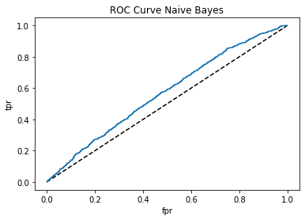

```python
from sklearn.naive_bayes import GaussianNB
from sklearn.metrics import confusion_matrix, classification_report, precision_score
from sklearn.model_selection import cross_val_predict

nb_clf = GaussianNB()
nb_clf_score = cross_val_score(nb_clf, features, labels, cv=5)
print("Average of all folds:")
print(np.average(nb_clf_score) * 100)

predictions = cross_val_predict(nb_clf, features, labels, cv = 5)
conf_matrix = confusion_matrix(labels, predictions)
tn, fp, fn, tp = conf_matrix.ravel()
print("Confusion Matrix: ")
print(str(conf_matrix))
print("FP Rate:", fp/(fp + tn) * 100)

nb_clf.fit(features_train, labels_train)
predict_probas = nb_clf.predict_proba(features_test)

fpr, tpr, thresholds = roc_curve(labels_test, predict_probas[:,1])
auc_score = roc_auc_score(labels_test, predict_probas[:,1])
print("AUC Score: ")
print(auc_score * 100)

plt.plot([0,1],[0,1],'k--') #plot the diagonal line
plt.plot(fpr, tpr, label='NB') #plot the ROC curve
plt.xlabel('fpr')
plt.ylabel('tpr')
plt.title('ROC Curve Naive Bayes')
plt.show()
```

### Naive Bayes Result Analysis

Prior to balancing the dataset, the average of all folds was far below 50%, at around 28%. The false positive rate was above 96% and stays above that even after fixing class imbalance.

Although balancing the dataset caused the overall accuracy to be a bit higher, the performance is still lackluster, and it does not correctly identify class 1 a majority of the time.

Therefore, we don't believe this is an accurate classifier for our data.

## KNN Classifier

```
Best params:
{'knn__n_neighbors': 14, 'pca__n_components': 3}

Best Accuracy:
60.96373216400723
AUC Score:
71.49509702013493
```

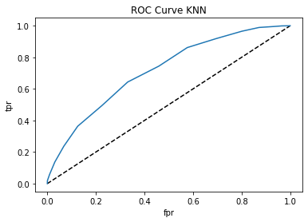

```python
from sklearn.preprocessing import StandardScaler
from sklearn.decomposition import PCA
from sklearn.neighbors import KNeighborsClassifier
from sklearn.pipeline import Pipeline

scaler = StandardScaler(with_mean=True, with_std=True)
decomp_pca = PCA()
knn_clf = KNeighborsClassifier()
pipeline = Pipeline(steps=[('scaler', scaler), ('pca', decomp_pca), ('knn', knn_clf)])


param_grid = {
    'pca__n_components': [2, 3],
    'knn__n_neighbors': [14, 19, 24]
}

grid_search = GridSearchCV(pipeline, param_grid, cv=5, scoring='accuracy')
grid_search.fit(features, labels)
print("Best params: ")
print(grid_search.best_params_)
print("\nBest Accuracy: ")
print(grid_search.best_score_*100)

predict_probas = grid_search.predict_proba(features_test)

fpr, tpr, thresholds = roc_curve(labels_test, predict_probas[:,1])

auc_score = roc_auc_score(labels_test, predict_probas[:,1])
print("AUC Score: ")
print(auc_score * 100)

plt.plot([0,1],[0,1],'k--') #plot the diagonal line
plt.plot(fpr, tpr, label='KNN') #plot the ROC curve
plt.xlabel('fpr')
plt.ylabel('tpr')
plt.title('ROC Curve KNN')
plt.show()
```

#### KNN Result Analysis

Prior to fixing the class imbalance problem, we had an accuracy of close to 75%. After resolving class imbalance, we now have an accuracy of ~61%

This means the KNN classifier has a worse performance than the decision tree when based on accuracy alone - however, the AUC score is a bit larger, meaning that class 1 is getting predicted correctly a bit more often. This is something we may have to consider when choosing our "best" classifier.

## SVM Classifier

```
Best params:
{'pca__n_components': 4, 'svm__kernel': 'rbf'}
Accuracy:
55.543499704083644
AUC Score:
58.78475785876102
```

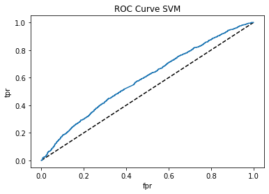

```
Classification Report:
```

```
{'0': {'precision': 0.5511280931586608,
  'recall': 0.5975537581376997,
  'f1-score': 0.5734027449124467,
  'support': 10138},
 '1': {'precision': 0.5605342524773804,
  'recall': 0.5133162359439731,
  'f1-score': 0.5358871382967768,
  'support': 10138},
 'accuracy': 0.5554349970408364,
 'macro avg': {'precision': 0.5558311728180206,
  'recall': 0.5554349970408364,
  'f1-score': 0.5546449416046118,
  'support': 20276},
 'weighted avg': {'precision': 0.5558311728180205,
  'recall': 0.5554349970408364,
  'f1-score': 0.5546449416046118,
  'support': 20276}}
```

```python
from sklearn.svm import SVC

svc = SVC(probability=True)
pipeline = Pipeline(steps=[('scaler', scaler), ('pca', decomp_pca), ('svm', svc)])
param_grid = {
    'pca__n_components': list(range(2, 5)),
    'svm__kernel': ['linear', 'rbf', 'poly']
}

grid_search = GridSearchCV(pipeline, param_grid, cv=5, scoring='accuracy')
grid_search.fit(features, labels)
print("Best params: ")
print(grid_search.best_params_)
predictions = cross_val_predict(grid_search, features, labels, cv = 5)
report = classification_report(labels, predictions, output_dict = True)
print("Accuracy: ")
print(str(report['accuracy']*100))

predict_probas = grid_search.predict_proba(features_test)

fpr, tpr, thresholds = roc_curve(labels_test, predict_probas[:,1])

auc_score = roc_auc_score(labels_test, predict_probas[:,1])
print("AUC Score: ")
print(auc_score * 100)

plt.plot([0,1],[0,1],'k--') #plot the diagonal line
plt.plot(fpr, tpr, label='SVM') #plot the ROC curve
plt.xlabel('fpr')
plt.ylabel('tpr')
plt.title('ROC Curve SVM')
plt.show()

print("\n\nClassification Report: ")
report
```

#### SVM Result Analysis

Before resolving our class imbalance problem, we were getting 75.15% accuracy and an F1 score of 0.429.

After resolving the class imbalance, the accuracy for this classifier is only 55% so it's only slightly better than guessing. The AUC is also not high, which means that there is a lot of misclassification occuring for class 1.

Because of these factors, we do not believe this to be a reliable classifier for our data.

## MLP Classifier (Neural Nets)

[output not shown]

[output cut: 16 more lines]

```
Best params:
{'mlp__activation': 'relu', 'mlp__hidden_layer_sizes': 50}
```

[output not shown]

[output cut: 235 more lines]

[output not shown]

```
AUC Score:
66.02172585766588
```

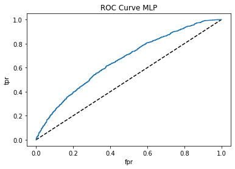

```
Average Accuracy:
59.17836235976234
```

```python
# initialize the two components of the pipeline: the scalar, and the MLP classifier
from sklearn.neural_network import MLPClassifier

mlp = MLPClassifier()

# create the pipeline and construct the param_grid
pipeline = Pipeline(steps=[('scaler', scaler), ('mlp', mlp)])
param_grid = {
    'mlp__hidden_layer_sizes': list(range(30, 60, 10)),
    'mlp__activation': ["logistic", "tanh", "relu"]
}

# create a grid search cv with our pipeline, 5 folds, param_grid, and score on accuracy. Fit to all data.
grid_search = GridSearchCV(pipeline, param_grid, cv=5, scoring='accuracy')
grid_search.fit(features, labels)

# display the best params chosen by the grid search cv
print("Best params: ")
print(grid_search.best_params_)

# make predictions using the selected params, and get probabilities
# that a row is in a class
predictions = cross_val_score(grid_search, features, labels, cv=5)
predict_probas = grid_search.predict_proba(features_test)

#replace these fpr and tpr with the results of your roc_curve
fpr, tpr, thresholds = roc_curve(labels_test, predict_probas[:,1])

# display the auc score and plot the results
auc_score = roc_auc_score(labels_test, predict_probas[:,1])
print("AUC Score: ")
print(auc_score * 100)

plt.plot([0,1],[0,1],'k--') #plot the diagonal line
plt.plot(fpr, tpr, label='MLP') #plot the ROC curve
plt.xlabel('fpr')
plt.ylabel('tpr')
plt.title('ROC Curve MLP')
plt.show()

print("Average Accuracy: ")
print(predictions.mean()*100)
```

#### MLP Result Analysis

Prior to fixing the class imbalance problem, we had an accuracy of close to 75%. After resolving class imbalance, we now have an accuracy of ~59%

## Ensemble Classifier - Random Forest

```
AUC Score:
82.99597612567698
```

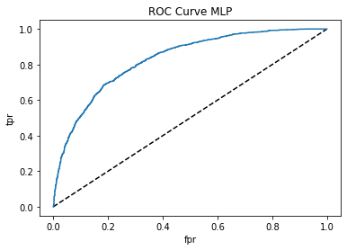

```
Average Accuracy:
76.83473540592007
```

```python
from sklearn.ensemble import RandomForestClassifier

rfc = RandomForestClassifier()

param_grid = {
    'max_depth': list(range(35,55)),
    'min_samples_leaf': [8, 10, 12],
    'max_features': ["sqrt", "log2"]
}

grid_search = GridSearchCV(rfc, param_grid, cv=5, scoring='accuracy')
grid_search.fit(features, labels)
predictions = cross_val_score(grid_search, features, labels, cv=5)

predict_probas = grid_search.predict_proba(features_test)

fpr, tpr, thresholds = roc_curve(labels_test, predict_probas[:,1])

auc_score = roc_auc_score(labels_test, predict_probas[:,1])
print("AUC Score: ")
print(auc_score * 100)

plt.plot([0,1],[0,1],'k--') #plot the diagonal line
plt.plot(fpr, tpr, label='MLP') #plot the ROC curve
plt.xlabel('fpr')
plt.ylabel('tpr')
plt.title('ROC Curve MLP')
plt.show()

print("Average Accuracy: ")
print(predictions.mean()*100)
```

## Ensemble Classifier - ADA Boost

[output not shown]

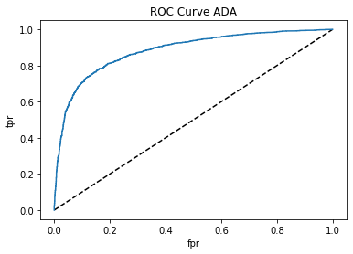

```
Average Accuracy:
95.56105838375156
```

```python
from sklearn.ensemble import AdaBoostClassifier


param_grid = {"base_estimator__criterion" : ["gini", "entropy"],
              "base_estimator__splitter" :   ["best", "random"],
              "n_estimators": [10, 50, 100, 150]
             }


DTC = DecisionTreeClassifier(random_state = 11, max_features = "auto", class_weight = "balanced",max_depth = None)

ABC = AdaBoostClassifier(base_estimator = DTC)

# run grid search
grid_search = GridSearchCV(ABC, param_grid=param_grid, scoring = 'roc_auc')

grid_search.fit(features, labels)

predictions = cross_val_score(grid_search, features, labels, cv=5)

predict_probas = grid_search.predict_proba(features_test)

fpr, tpr, thresholds = roc_curve(labels_test, predict_probas[:,1])

auc_score = roc_auc_score(labels_test, predict_probas[:,1])
print("AUC Score: ")
print(auc_score * 100)

plt.plot([0,1],[0,1],'k--') #plot the diagonal line
plt.plot(fpr, tpr, label='ADA') #plot the ROC curve
plt.xlabel('fpr')
plt.ylabel('tpr')
plt.title('ROC Curve ADA')
plt.show()

print("Average Accuracy: ")
print(predictions.mean()*100)
```

#### ADA Boost Result Analysis

Before resolving our class imbalance problem, we were getting ~75% accuracy

After resolving the class imbalance, the accuracy for this classifier is 95.56%, which is a large improvement. Additionally, the AUC score is higher than all other classifiers, showing that our false positive rate is only about 20% from guessing visually.

Due to the high accuracy, high AUC score, and relatively low false positive rate, our best classifier is ADA Boost.

# Final Model

```python
import pickle

#set final model to the latest (most accurate) grid search (ADA Boosting)
final_model = grid_search
filename = 'finalized_model.sav'
pickle.dump(final_model, open(filename, 'wb'))
print("Model outputted")
```

```
Model outputted
```

# Outcome

### Our Methodology

#### Cleaning

Our inital dataset contained over 300,000 lines of data. Due to the limitations of using our own machines, we took a sample of 25,000 lines of data to work with and cleaned the data from there.

When cleaning the data, we dropped all columns that wouldn't be "predictive features" or were repetetive in nature. Many of our columns featured parings such as "basis" and "basis_code", which were essentially the same thing but the code version was abbreviated. For the purposes of our project, we worked with the encoded columns.

We chose to get the employee's age from the original "date of birth" column, as we believed a numerical value would be much easier to work with.

We also had to refine our class categories into 2 distinct classes. Originally there were 13 various case outcomes, but we determined which case outcomes ended in favor of the employee or the employer and discarded any cases whose outcomes do not fit these two categories.

Two of our features, issue_code and basis_code, also had a wide variety of outcomes. For the purposes of clarity and reducing dimensionality, we grouped them into distinct classes as described in "Fix 'Issue Code' column" and "Fix 'Basis Code' column". We also abbreviated the NAISCs code, as only the first 3 numbers of the codes were necessary to identify a company's sector and subsector.

#### Data Analysis

After looking at the proportion of class 0 to class 1, we found out that class 0 greatly outnumbered class 1 at around 3:1. We recognized this as a class imbalance problem, and decided to resolve it using resampling the minority class (class 1) with replacement.

We looked into using a cost matrix since we figured out it would be better to someone not to move forward with a lawsuit rather than telling them to move forward with it and they lose. However, after some research we found out cost matrix is not implemented into SKLearn.

### Result Analysis

From testing our dataset with multiple classifiers, we have found two classifiers that lead to fairly desirable results - Ensemble (random forest) and ADA boost. Out of these two classifiers, ADA proved to be the best with a high accuracy of ~95.56% and a high AUC score of 88.27.

We attempted to extract what features make a case more or less likely to end in favor of the employee; however, through our research we found that these factors were basically impossible to reverse engineer from the ADA boost classifier, meaning that we were unable to examine what biases could possibly exist in employee complaints cases.

When we realized we had run into the class imbalance problem, it became apparent that the number of cases ruled in favor of the employer greatly outweighed the number of cases ruled in favor of the employee. Although we can't point to distinct factors that would make a case more or less likely for an employee to win, we could perhaps run an employee's case information through the ADA Boost classifier to give them an idea of whether or not it was likely their case would end in their favor.